# Homework 1

## Sky Cen

### Question 3

```python
import math
import random
import matplotlib.pyplot as plt
import numpy as np
```

Parse and store data points from text file

```python
filename = "hw1-data 2-1.txt"

data = []
with open(filename, "r") as file:
    for line in file:
        data.append(list(map(float, line.split())))
```

Define distance metric

```python
def euclidean_distance(a: list[float], b: list[float]):
    sum = 0
    for i in range(len(a)):
        sum += (a[i] - b[i]) ** 2
    return math.sqrt(sum)
```

Define kmeans function

```python
def kmeans(k: int, data: list[list[float]]):
    converged = False
    data_centroids = [-1] * len(data)
    centroids = np.random.uniform(low=[0, 0], high=[1, 1], size=(k, 2))

    while not converged:
        converged = True

        # E step: assignment
        for i in range(len(data)):
            min_ind = -1
            min_distance = float("inf")
            for j in range(k):
                distance = euclidean_distance(data[i], centroids[j])
                if distance < min_distance:
                    min_distance = distance
                    min_ind = j
            if min_ind != data_centroids[i]:
                data_centroids[i] = min_ind
                converged = False

        # M step: update centroids
        if not converged:
            new_centroids = [[0 for _ in sublist] for sublist in centroids]
            counts = [0] * k
            for i in range(len(data)):
                new_centroids[data_centroids[i]] = \
                [x + y for x, y in zip(new_centroids[data_centroids[i]], data[i])]
                counts[data_centroids[i]] += 1
            for i in range(k):
                if counts[i] > 0:
                    new_centroids[i] = [x / counts[i] for x in new_centroids[i]]
                else:
                    new_centroids[i] = centroids[i]
            centroids = new_centroids

    # Plot data points and centroids
    x = []
    y = []
    for i in range(len(data)):
        x.append(data[i][0])
        y.append(data[i][1])

    colormap = np.array(['r', 'g', 'b'])
    plt.scatter(x, y, c=colormap[data_centroids])

    x = []
    y = []
    for i in range(len(centroids)):
        x.append(centroids[i][0])
        y.append(centroids[i][1])

    plt.scatter(x, y, s=200, marker='x', c='black')
```

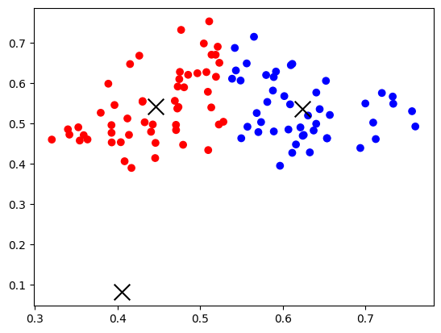

```python
kmeans(3, data)
```

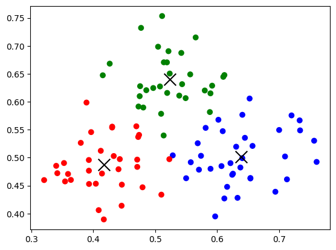

```python
kmeans(3, data)
```

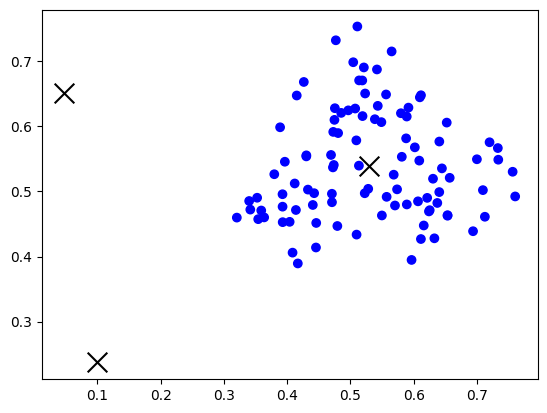

```python
kmeans(3, data)
```

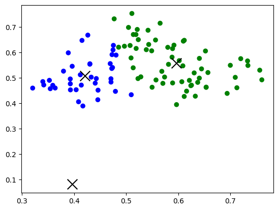

```python
kmeans(3, data)
```

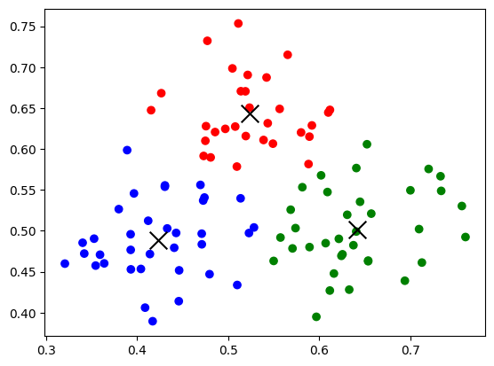

```python
kmeans(3, data)
```

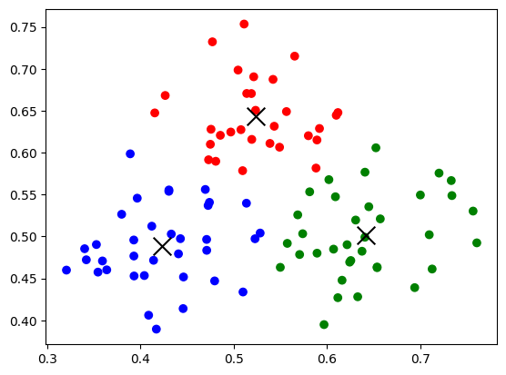

```python
kmeans(3, data)
```

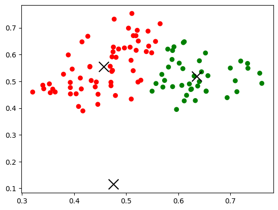

```python
kmeans(3, data)
```

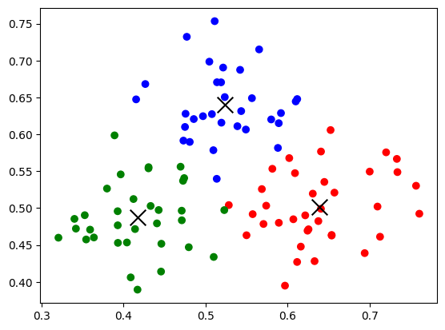

```python
kmeans(3, data)
```

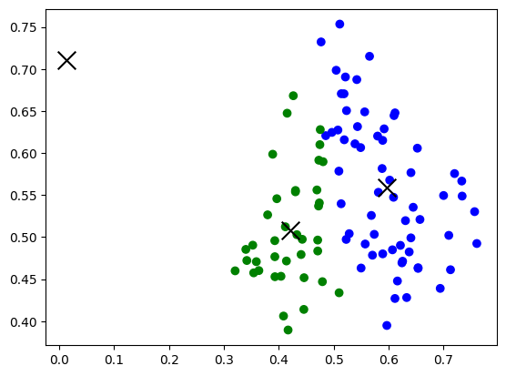

```python
kmeans(3, data)
```

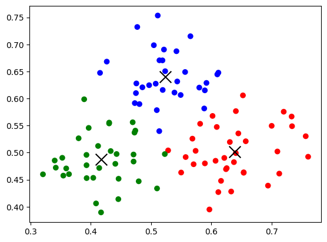

```python
kmeans(3, data)
```

3i) The common tendancy of k-means on this dataset with the given initialization is to produce 3 clusters as shown in the image above (image 10). After multiple runs of the algorithm, it seems like this result occurs around 50% of the time.

3ii) The outlier occurence of k-means occurs when a cluster is initialized very far from the data points, resulting in centroids that have no data points assigned to them. In other words, there may be scenarios where only two centroids correspond to a cluster (ex: image 1) or scenarios where only one centroid corresponds to a cluster (ex: image 3). This highlights one of the issues of the k-means clustering algorithm: its sensitivity to centroid initialization. More specifically, different centroid initialization can lead to different results. Sometimes, results may be suboptimal compared to others. Additionally, centroids could be initialized in a way such that no data points are assigned to a centroid or two centroids are initialized at the same location. This is an issue because during each iteration, the centroids are updated by taking the average of all data points. If a centroid has no data points, the average of data points would have a divide by 0 error. To fix this issue, centroids can be initialized randomly from the set of all data points, ensuring at least one data point will be assigned to every centroid.

### Question 4

4a) For k-means, the time complexity for assignment per data point is $O(kd)$ where $k$ is the number of clusters and $d$ is the dimensionality of the data. This is because each data point is assigned to a cluster by computing the distances of that data point to every other centroid. Since there are $k$ centroids, and $d$ operations per distance computation, the time complexity of assigning a single data point to a centroid is $O(kd)$. The space complexity of storing centroids for k-means is $O(kd)$. This is because there are $k$ centroids each with dimension $d$ that need to be stored.

For product quantization, the time complexity for assignment per iteration is $O(k^{1/m}d)$. Let $m$ be the number of sub-vectors each data point is split into. So, each data point has $O(m k d / m) = O(kd)$ distance computations because there are $m$ sub-vectors, $k$ centroids and a dimension of $d / m$. However, product quantization creates $k^m$ clusters compared to the $k$ clusters of k-means. In order for a proper comparison, we must consider the complexity of computing the same number of clusters. So, we end up with a final assignment complexity of $O(k^{1/m}d)$. The space complexity of storing centroids is $O(k^{1/m}d)$. This is because there are a total of $O(mk)$ centroids with each centroid having a dimension of $O(d/m)$. So, the space complexity is $O(mkd/m) = O(kd)$. Similar to before, in order to "normalize" the comparison, we end up with a space complexity of $O(k^{1/m}d)$.

4b) From the computational complexities given above, it is clear that product quantization becomes more favorable compared to k-means as $m$ increases. In order for $m$ to increase reasonably, $d$ must also increase. That is, for $m$ to be "large", $d$ must also be "large". This is because the dimensionality, $d$, of each vector is divided into $m$ groups. So, product quantization is signficantly more efficient than k-means when working with high dimensional data where product quantization can utilize the ability to divide data points into lower dimensional data points.